# HW5

Sydney Ball

2024-02-21

```r
library(tidyverse)
library(Lahman)
```

#### Question 1:

Shoe that Batting is not a tibble.

```r
is_tibble(Batting)
```

```
## [1] FALSE
```

#### Question 2:

Without hard coding, show the number of rows and columns in Batting.

```r
dimensions <- dim(Batting)

dimensions[1]
```

```
## [1] 112184
```

```r
dimensions[2]
```

```
## [1] 22
```

#### Question 3:

Convert the data frame from Batting into a tibble.

```r
as_tibble(Batting) -> BattingT
is_tibble(BattingT)
```

```
## [1] TRUE
```

#### Question 4:

se dplyr coding to determine how many and which players hit more than 30 home runs in 1991. (Select playerID, teamID, yearID, and HR)

```r
BattingT%>%
  select(playerID, teamID, yearID, HR)%>%
  filter(HR>=30)%>%
  filter(yearID == 1991)
```

```
## # A tibble: 12 × 4
##    playerID  teamID yearID    HR
##    <chr>     <fct>   <int> <int>
##  1 cansejo01 OAK      1991    44
##  2 cartejo01 TOR      1991    33
##  3 dawsoan01 CHN      1991    31
##  4 fieldce01 DET      1991    44
##  5 gantro01  ATL      1991    32
##  6 johnsho01 NYN      1991    38
##  7 mcgrifr01 SDN      1991    31
##  8 ripkeca01 BAL      1991    34
##  9 tartada01 KCA      1991    31
## 10 tettlmi01 DET      1991    31
## 11 thomafr04 CHA      1991    32
## 12 willima04 SFN      1991    34
```

#### Question 5:

Use subsetting R code to determine the mean for HR in 1991.

We determine that the mean number of homeruns in 1991 is about 34.6.

```r
BattingT%>%
  select(playerID,teamID,yearID, HR)%>%
   filter(HR>=30)%>%
  filter(yearID == 1991)%>%
  summarize(HR = mean(HR , na.rm = TRUE) )
```

```
## # A tibble: 1 × 1
##      HR
##   <dbl>
## 1  34.6
```

#### Question 6:

Use dplyr code to determine how many and which players hit more than 40 SB in 1990. (Select playerID, teamID, yearID, and HR)

```r
BattingT%>%
  select(playerID, teamID, yearID, HR, SB)%>%
  filter(SB>40)%>%
  filter(yearID == 1990)
```

```
## # A tibble: 11 × 5
##    playerID  teamID yearID    HR    SB
##    <chr>     <fct>   <int> <int> <int>
##  1 bondsba01 PIT      1990    33    52
##  2 butlebr01 SFN      1990     3    51
##  3 colemvi01 SLN      1990     6    77
##  4 deshide01 MON      1990     4    42
##  5 henderi01 OAK      1990    28    65
##  6 kellyro01 NYA      1990    15    42
##  7 nixonot01 MON      1990     1    50
##  8 raineti01 MON      1990     9    49
##  9 roberbi01 SDN      1990     9    46
## 10 saxst01   NYA      1990     4    43
## 11 yeldier01 HOU      1990     1    64
```

#### Question 7:

Use subsetting R code to determine the mean for SB in 1990.

```r
BattingT%>%
  select(playerID,teamID,yearID,HR,SB)%>%
   filter(SB>40)%>%
  filter(yearID == 1990)%>%
  summarize(SB = mean(SB , na.rm = TRUE) )
```

```
## # A tibble: 1 × 1
##      SB
##   <dbl>
## 1  52.8
```

#### Question 8:

Use R code to create side by side boxplots showing greater than 23HR counts for players in 1990 and 1991.

```r
filtered_data <- BattingT %>%
  select(playerID, yearID, HR)%>%
  filter(yearID %in% c(1990, 1991))%>%
  filter(HR > 23)%>%
  arrange(desc(HR))

filtered_data
```

```
## # A tibble: 59 × 3
##    playerID  yearID    HR
##    <chr>      <int> <int>
##  1 fieldce01   1990    51
##  2 cansejo01   1991    44
##  3 fieldce01   1991    44
##  4 sandbry01   1990    40
##  5 mcgwima01   1990    39
##  6 johnsho01   1991    38
##  7 cansejo01   1990    37
##  8 strawda01   1990    37
##  9 mcgrifr01   1990    35
## 10 mitchke01   1990    35
## # ℹ 49 more rows
```

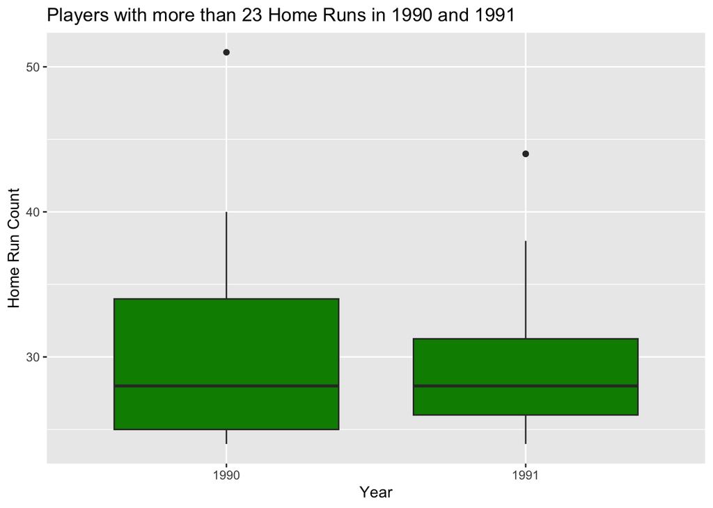

```r
ggplot(filtered_data, aes(x = as.factor(yearID), y = HR)) +
  geom_boxplot(fill = "green4") +
  labs(x = "Year", y = "Home Run Count", title = "Players with more than 23 Home Runs in 1990 and 1991")
```

#### Question 9:

The boxplots below summarize the combined homerun output for individual players for the years 1990 and 1991. (The individual players on indicated teams who hit more than 23 homeruns)

```r
filtered_data2 <- BattingT %>%
  select(playerID, yearID, HR, teamID)%>%
  filter(yearID %in% c(1990, 1991))%>%
  filter(HR > 23)%>%
  arrange(desc(HR))

filtered_data2
```

```
## # A tibble: 59 × 4
##    playerID  yearID    HR teamID
##    <chr>      <int> <int> <fct>
##  1 fieldce01   1990    51 DET
##  2 cansejo01   1991    44 OAK
##  3 fieldce01   1991    44 DET
##  4 sandbry01   1990    40 CHN
##  5 mcgwima01   1990    39 OAK
##  6 johnsho01   1991    38 NYN
##  7 cansejo01   1990    37 OAK
##  8 strawda01   1990    37 NYN
##  9 mcgrifr01   1990    35 TOR
## 10 mitchke01   1990    35 SFN
## # ℹ 49 more rows
```

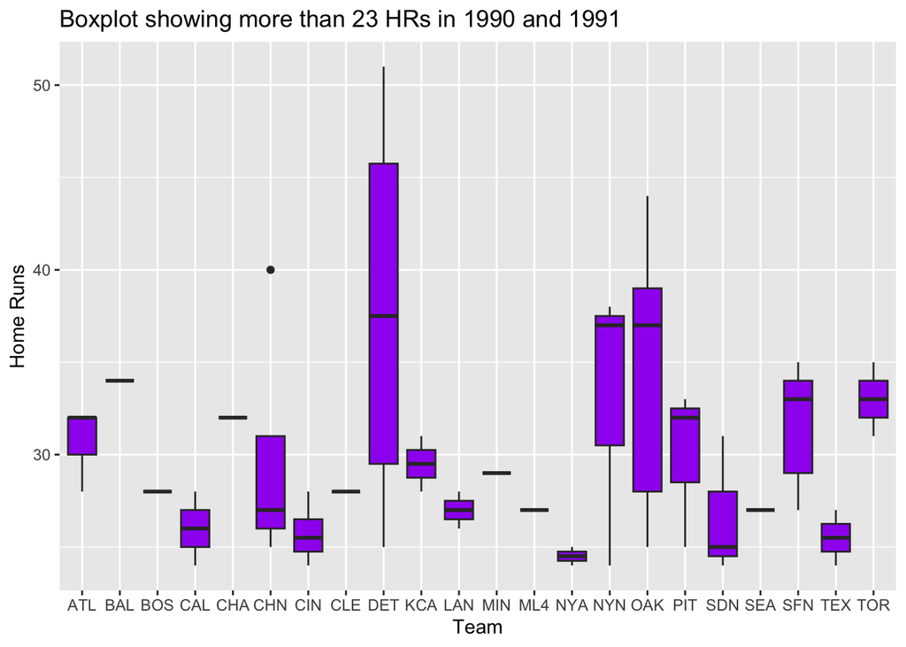

```r
ggplot(filtered_data2, aes(x = as.factor(teamID), y = HR)) +
  geom_boxplot(fill = "purple") +
  labs(x = "Team", y = "Home Runs", title = "Boxplot showing more than 23 HRs in 1990 and 1991")
```